# Praca domowa nr 2

Jakub Rymarski

2022-10-29

## Wstęp

W dokumencie przedstawię rozwiązanie zadania z Pracy Domowej nr 2 z przedmiotu Techniki Wizualizacji Danych. Praca polegała na znalezieniu wykresu, opublikowanego w mediach w ciągu ostatnich 2 tygodni i poprawieniu go. Znaleziony przeze mnie wykres znajduje się na stronie internetowej:

https://businessinsider.com.pl/twoje-pieniadze/inflacja-inflacja-ale-na-zmarlych-polacy-oszczedzac-nie-zamierzaja/mm2kqh5

Został opublikowany 29 października 2022 roku.

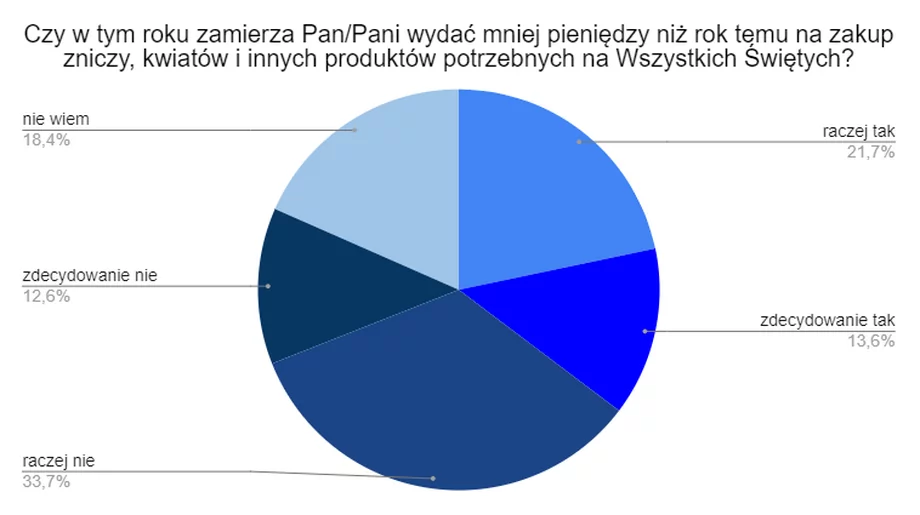

```r
  knitr::include_graphics("orygw.webp")
```

Najpierw pokażę kod, dzięki któremu poprawiłem ten wykres. Następnie uzasadnię, dlaczego mój wykres jest lepszy niż ten oryginalny.

## Kod

```r
library(ggplot2)
library(dplyr)
library(RColorBrewer)

#Znajduję odpowiednią paletę barw - diverging ze strony color brewer.

RColorBrewer::brewer.pal(n = 5, name = "PuOr")
```

```
## [1] "#E66101" "#FDB863" "#F7F7F7" "#B2ABD2" "#5E3C99"
```

```r
#Tworzę ramkę danych z wartościami jak na poprawianym wykresie.

odpowiedź<-c("zdecydowanie tak", "raczej tak", "nie wiem", "raczej nie", "zdecydowanie nie")
procent<-c(13.6, 21.7, 18.4, 33.7, 12.6)
df<-data.frame(odpowiedź, procent)
df
```

```
##          odpowiedź procent
## 1 zdecydowanie tak    13.6
## 2       raczej tak    21.7
## 3         nie wiem    18.4
## 4       raczej nie    33.7
## 5 zdecydowanie nie    12.6
```

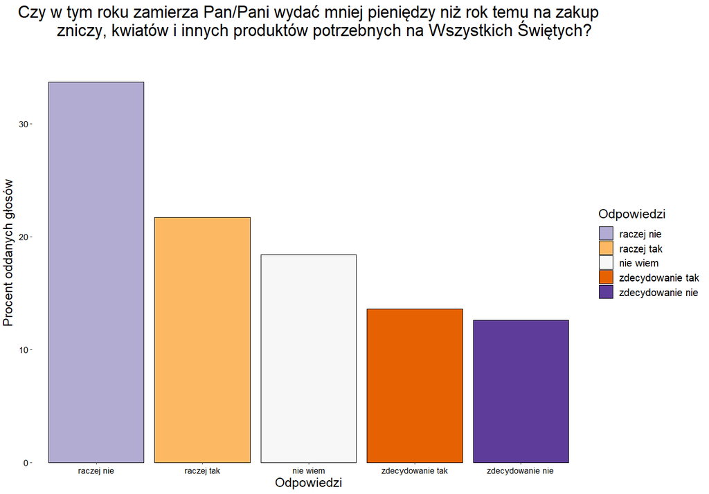

```r
#Tworzę pomocniczy wektor kolorów, które będą odpowiadały danej odpowiedzi.

kolory<-c("#B2ABD2", "#FDB863", "#F7F7F7", "#E66101", "#5E3C99")

#Sortuję odpowiedzi względem uzyskanych procentów.

df <- df %>%
  mutate(odpowiedź = forcats::fct_reorder(odpowiedź, -procent))

#Tworzę wykres słupkowy.
options(repr.plot.width =5, repr.plot.height =9)

p_slup<-ggplot(df, aes(y = procent, x=odpowiedź, fill=odpowiedź))+
  geom_col(color="black")+
  scale_fill_manual(values=kolory)+
  #scale_fill_manual(values = kolory)+
  scale_y_continuous(expand = expansion(mult =c(0, 0.1)))+
  labs(title = "Czy w tym roku zamierza Pan/Pani wydać mniej pieniędzy niż rok temu na zakup
       zniczy, kwiatów i innych produktów potrzebnych na Wszystkich Świętych?",
       x="Odpowiedzi",
       y="Procent oddanych głosów",
       fill="Odpowiedzi")+
  theme(rect = element_blank(),
        plot.title = element_text(size=20, hjust = 0.5),
        legend.title = element_text(size=15),
        legend.text=element_text(size=12) ,
        axis.title.x = element_text(size=15),
        axis.text.x = element_text(size=10, color="black"),
        axis.title.y = element_text(size=15, vjust=+2),
        axis.text.y = element_text(size=10, color="black"))
```

## Dlaczego mój wykres jest lepszy?

Oryginalny wykres ukazuje procent ankietowanych, którzy udzielili jednej z pięciu odpowiedzi: “zdecydowanie tak”, “raczej tak”, “nie wiem”, “raczej nie”, “zdecydowanie nie” na pytanie “Czy w tym roku zamierza Pan/Pani wydać mniej pieniędzy niż rok temu na zakup zniczy, kwiatów i innych produktów potrzebnych na Wszystkich Świętych?”. Uważam, że mój wykres jest lepszy ponieważ:

### 1.

Orginalny wykres jest kołowy. Różnice pomiędzy danymi wartościami procentowymi dla poszczególnych odpowiedzi są dość małe, np. odpowiedzi “raczej tak” i “nie wiem” uzyskały odpowiednio 21,7% i 18,4% głosów. Na wykresie kołowym gołym okiem bardzo trudno stwierdzić, że procent odpowiedzi “raczej tak” był większy, a dodatkowo wywnioskować, że był większy o około 3% jest prawie niemożliwe. Na wykresie mamy co prawda napisane dokładne liczby, jednak nasze oko skupia w pierwszej kolejności uwagę na ładnym wizualnie wykresie kołowym i nie dostrzega liczb. Ja zdecydowałem się na wykres słupkowy, na którym od razu widać, których odpowiedzi było więcej. Bardzo łatwo zauważyć, który słupek jest wyższy i o ile.

### 2.

Wyniki na oryginalnym wykresie nie są w żaden sposób posortowane. Odpowiedź “raczej nie”, na którą zagłosowało najwięcej respondentów, została umieszczona między dwiema najmniej popularnymi odpowiedziami - “zdecydowanie tak” i “zdecydowanie nie”. Zaburza to pewien schemat. Jesteśmy przyzwyczajeni, że dane będą uszeregowane w kolejności. Tak właśnie zrobiłem na moim wykresie.

### 3.

Autor oryginalnego wykresu zastosował skalę kolorów, tak aby odróżnić odpowiedzi. Nie zastosował jednak odpowiednich barw. Odpowiedzi bardziej nagatywne są zaznaczone ciemniejszym niebieskim, a te pozytywne jaśniejszym niebieskim. Według mnie odcienie odpowiadające odpowiedziom “zdecydowanie nie” i “raczej nie” są bardzo podobne i trudno je odróżnić. Podobnie z kolorami “zdecydowanie tak” i “raczej tak”. W dodatku odpowiedź “nie wiem” ma kolor jasnoniebieski sugerując pozytywne brzmienie tej odpowiedzi, która jest w pełni neutralna. Na moim wykresie zdecydowałem zastosować się inną skalę kolorów. Odpowiedzi pozytywne “zdecydowanie tak” i “raczej tak” są reprezentowane przez dobrze kojarzące się człowiekowi kolory ciepłe. Odpowiedź neutralna “nie wiem” ma kolor najbardziej “przezroczysyty” - “biały”. Negatywne odpowiedzi przedstawione są za pomocą barw zimnych, a dokładnie odcieni fioletu. Oczywiście trzeba zróźnicować pewność odpowiedzi. Dlatego odpowiedzi “zdecydowanie” mają dużo bardziej wyrazisty kolor niż te “raczej”.